# Coronavirus US - Data Updates

davegoblue

11/8/2020

## Background

This file is designed to analyze coronavirus data from a single state using three data sources:

- [The COVID Tracking Project](https://covidtracking.com/) contains state-level data for cases, deaths, tests, and hospitalizations
- [USA Facts](https://usafacts.org/visualizations/coronavirus-covid-19-spread-map/) contains county-level data for cases, deaths, and population
- [CDC Weekly Deaths by Jurisdiction](https://catalog.data.gov/dataset/weekly-counts-of-deaths-by-jurisdiction-and-age-group) contains state-level data for total deaths by age cohort

Code for processing data from each of these sources is available in:

- Coronavirus_Statistics_CTP_v003
- Coronavirus_Statistics_USAF_v003
- Coronavirus_Statistics_CDC_v003

The goal of this file is to download updated data for the three main data sources, and to explore the performance of the segments as measured against the new data.

Functions are sourced and a variable mapping file is created:

```r
# All functions assume that tidyverse and its components are loaded and available
# Other functions are declared in the sourcing files or use library::function()
library(tidyverse)
```

```r
# If the same function is in both files, use the version from the more specific source
source("./Coronavirus_Statistics_Functions_Shared_v003.R")
source("./Coronavirus_Statistics_Functions_CTP_v003.R")
source("./Coronavirus_Statistics_Functions_USAF_v003.R")
source("./Coronavirus_Statistics_Functions_CDC_v003.R")

# Create a variable mapping file
varMapper <- c("cases"="Cases",
               "newCases"="Increase in cases, most recent 30 days",
               "casesroll7"="Rolling 7-day mean cases",
               "deaths"="Deaths",
               "newDeaths"="Increase in deaths, most recent 30 days",
               "deathsroll7"="Rolling 7-day mean deaths",
               "cpm"="Cases per million",
               "cpm7"="Cases per day (7-day rolling mean) per million",
               "newcpm"="Increase in cases, most recent 30 days, per million",
               "dpm"="Deaths per million",
               "dpm7"="Deaths per day (7-day rolling mean) per million",
               "newdpm"="Increase in deaths, most recent 30 days, per million",
               "hpm7"="Currently Hospitalized per million (7-day rolling mean)",
               "tpm"="Tests per million",
               "tpm7"="Tests per million per day (7-day rolling mean)"
               )
```

#### *Data Updates (early November)*

New data from COVID Tracking Project are downloaded and assessed against the existing state-level segments:

```r
# Use existing segments with updated data
locDownload <- "./RInputFiles/Coronavirus/CV_downloaded_201108.csv"
test_old_201108 <- readRunCOVIDTrackingProject(thruLabel="Nov 7, 2020",
                                               downloadTo=if (file.exists(locDownload)) NULL else locDownload,
                                               readFrom=locDownload,
                                               compareFile=readFromRDS("test_hier5_201025")$dfRaw,
                                               useClusters=readFromRDS("test_hier5_201025")$useClusters
                                               )
```

```
##
## File is unique by state and date
##
##
## Overall control totals in file:
## # A tibble: 1 x 3
##   positiveIncrease deathIncrease hospitalizedCurrently
##              <dbl>         <dbl>                 <dbl>
## 1          9761373        229238               9362912
##
## *** COMPARISONS TO REFERENCE FILE: compareFile
##
## Checkin for similarity of: column names
## In reference but not in current:
## In current but not in reference:
##
## Checkin for similarity of: states
## In reference but not in current:
## In current but not in reference:
##
## Checkin for similarity of: dates
## In reference but not in current:
## In current but not in reference: 2020-11-07 2020-11-06 2020-11-05 2020-11-04 2020-11-03 2020-11-02 2020-11-01 2020-10-31 2020-10-30 2020-10-29 2020-10-28 2020-10-27 2020-10-26 2020-10-25
##
## *** Difference of at least 5 and difference is at least 1%:
```

```
##          date             name newValue oldValue
## 1  2020-03-07 positiveIncrease      171      176
## 2  2020-03-11 positiveIncrease      502      509
## 3  2020-03-13 positiveIncrease     1059     1072
## 4  2020-03-18 positiveIncrease     3023     3089
## 5  2020-03-26 positiveIncrease    17544    17720
## 6  2020-03-28 positiveIncrease    19586    19925
## 7  2020-03-29 positiveIncrease    19570    19348
## 8  2020-03-30 positiveIncrease    21691    22042
## 9  2020-04-01 positiveIncrease    26078    25791
## 10 2020-04-06 positiveIncrease    28592    29002
## 11 2020-04-13 positiveIncrease    24758    25195
## 12 2020-04-15 positiveIncrease    29755    30307
## 13 2020-04-16 positiveIncrease    31489    30978
## 14 2020-04-24 positiveIncrease    33698    34231
```

[output cut: 36 more lines]

```
##
##
## *** Difference of at least 5 and difference is at least 1%:
```

```
##   state             name newValue oldValue
## 1    FL positiveIncrease   766305   776249
## 2    PR positiveIncrease    31067    61275
## 3    RI positiveIncrease    30581    30116
## Rows: 13,999
## Columns: 55
## $ date                        <date> 2020-11-07, 2020-11-07, 2020-11-07, 20...
## $ state                       <chr> "AK", "AL", "AR", "AS", "AZ", "CA", "CO...
## $ positive                    <dbl> 19306, 202482, 120828, 0, 257384, 95695...
## $ probableCases               <dbl> NA, 30709, 10812, NA, 6590, NA, 7501, 4...
## $ negative                    <dbl> 728589, 1224595, 1308477, 1768, 1608041...
## $ pending                     <dbl> NA, NA, NA, NA, NA, NA, NA, NA, NA, NA,...
## $ totalTestResultsSource      <chr> "totalTestsViral", "totalTestsViral", "...
## $ totalTestResults            <dbl> 747288, 1396368, 1418493, 1768, 1858835...
## $ hospitalizedCurrently       <dbl> 105, 1015, 633, NA, 1139, 3456, 1041, 4...
```

[output cut: 79 more lines]

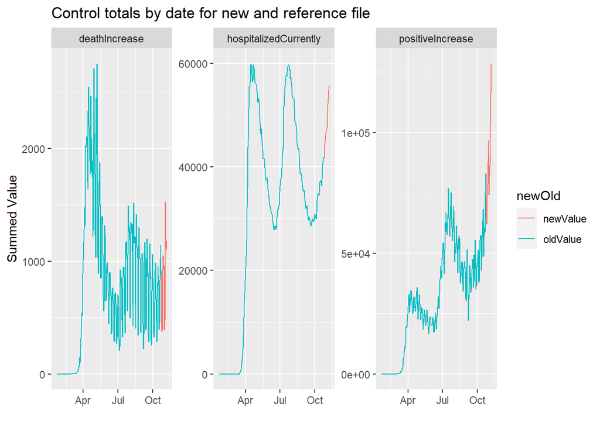

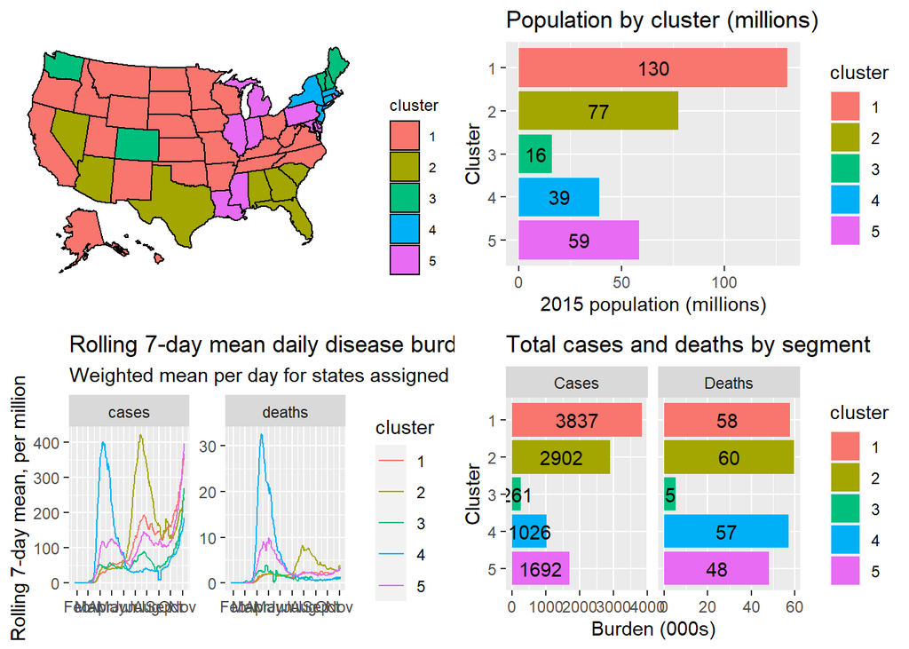

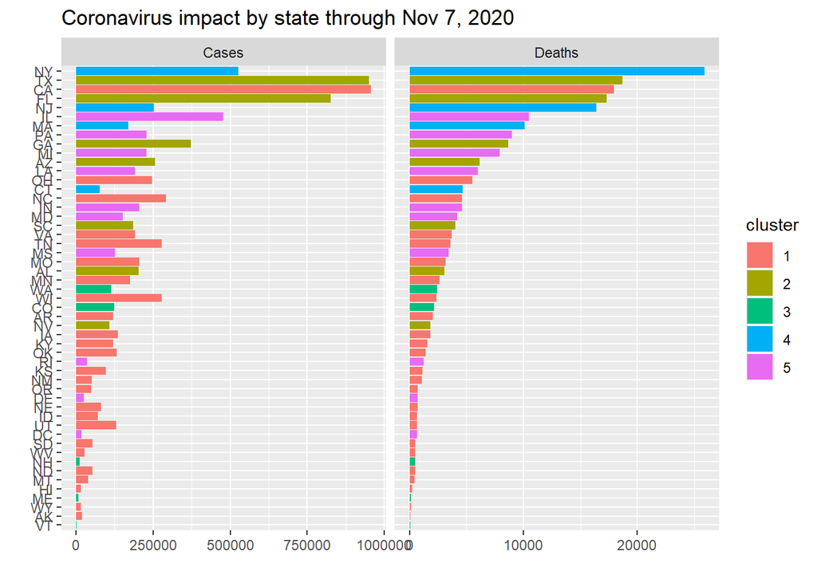

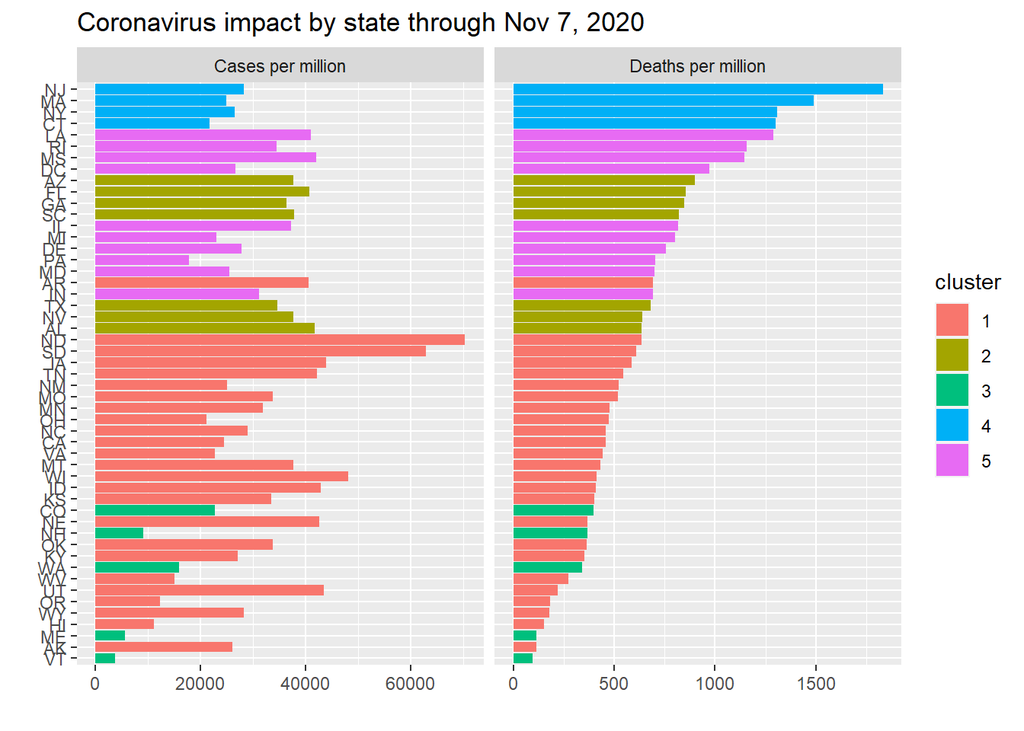

```
##
## Recency is defined as 2020-10-09 through current
##
## Recency is defined as 2020-10-09 through current
```

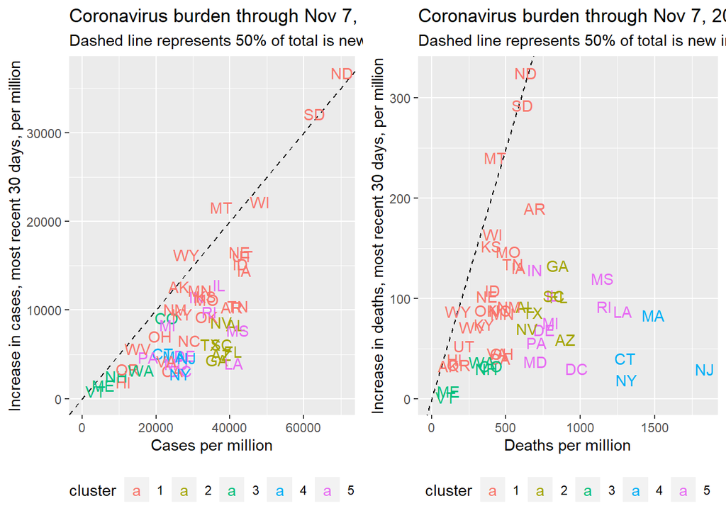

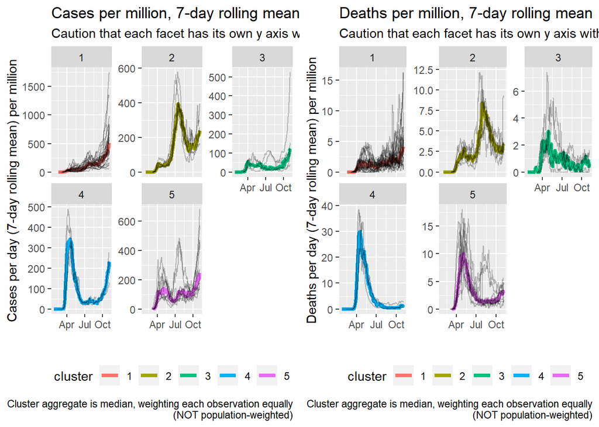

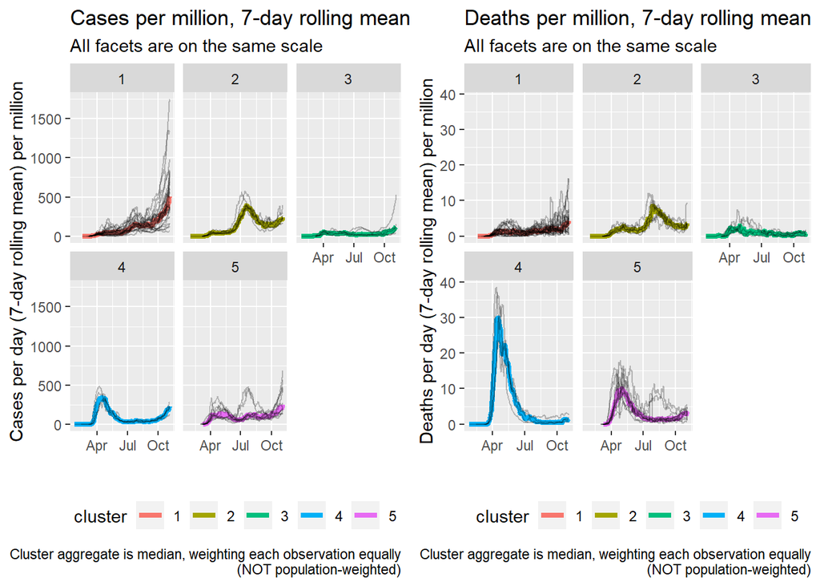

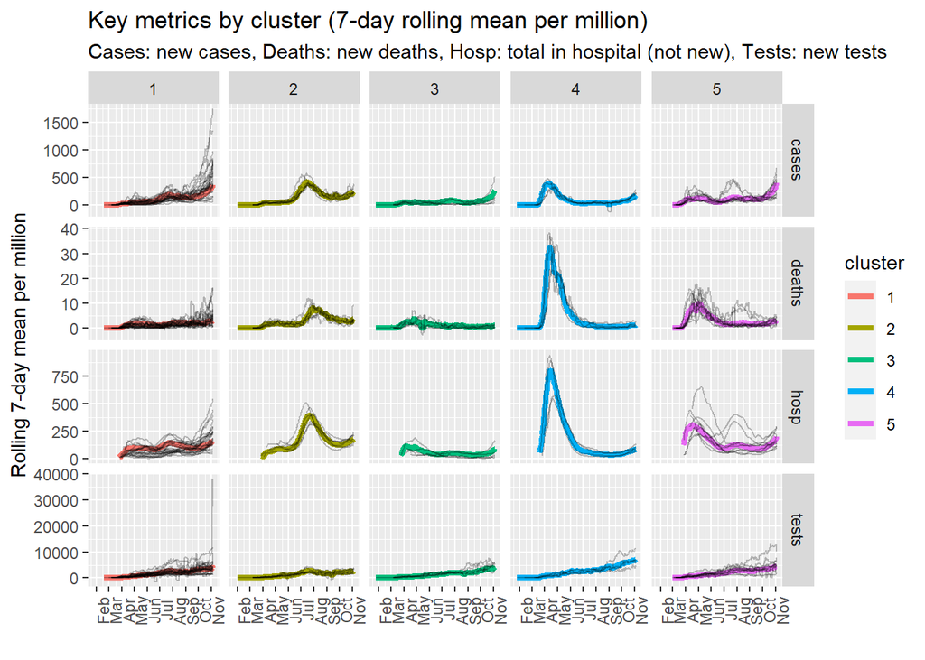

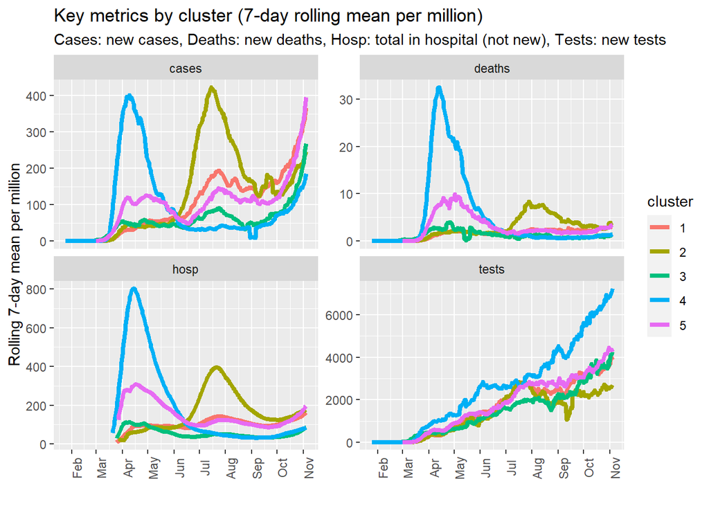

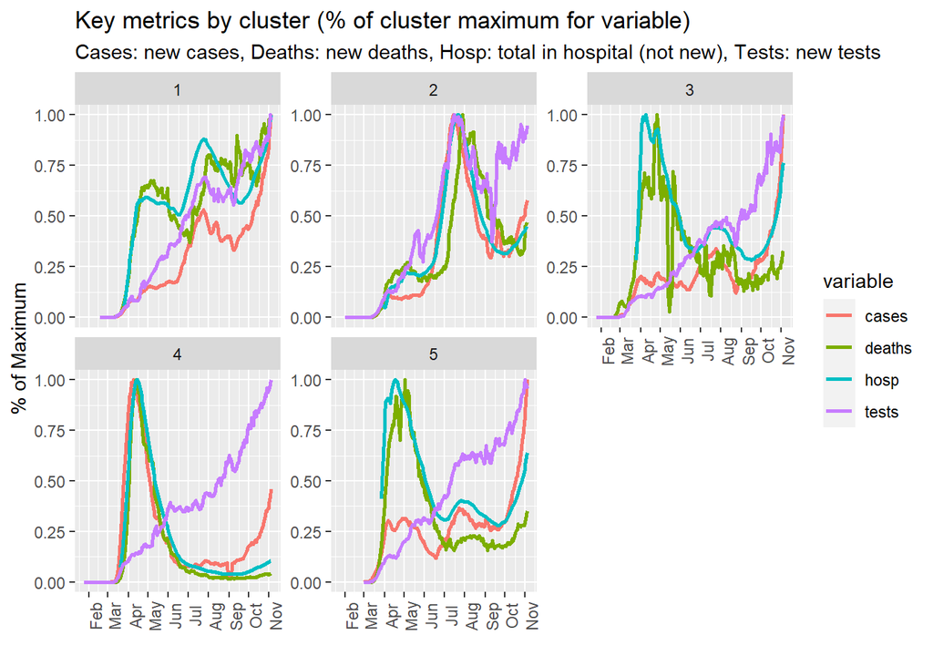

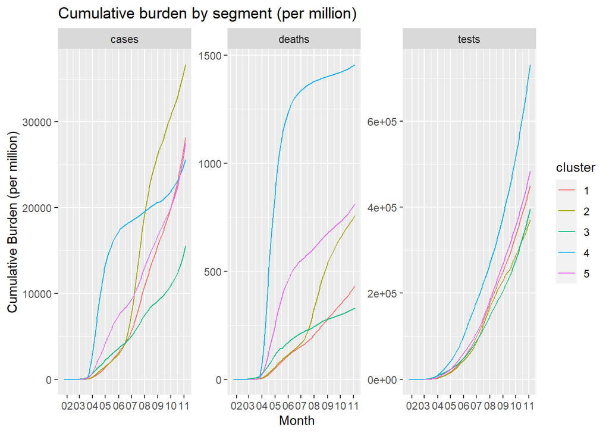

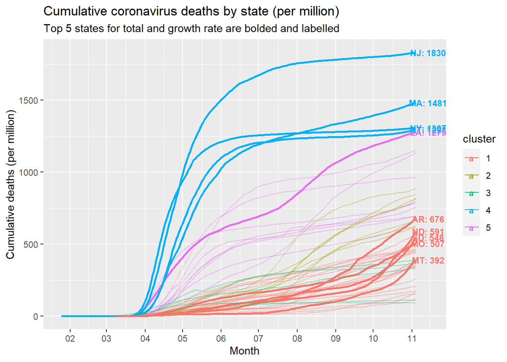

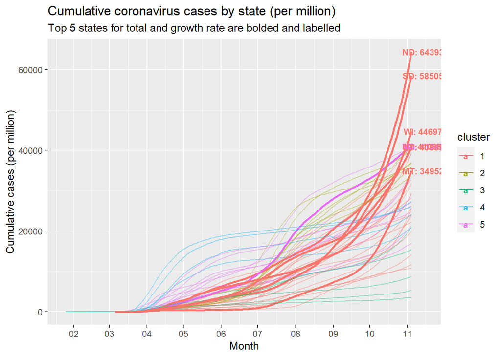

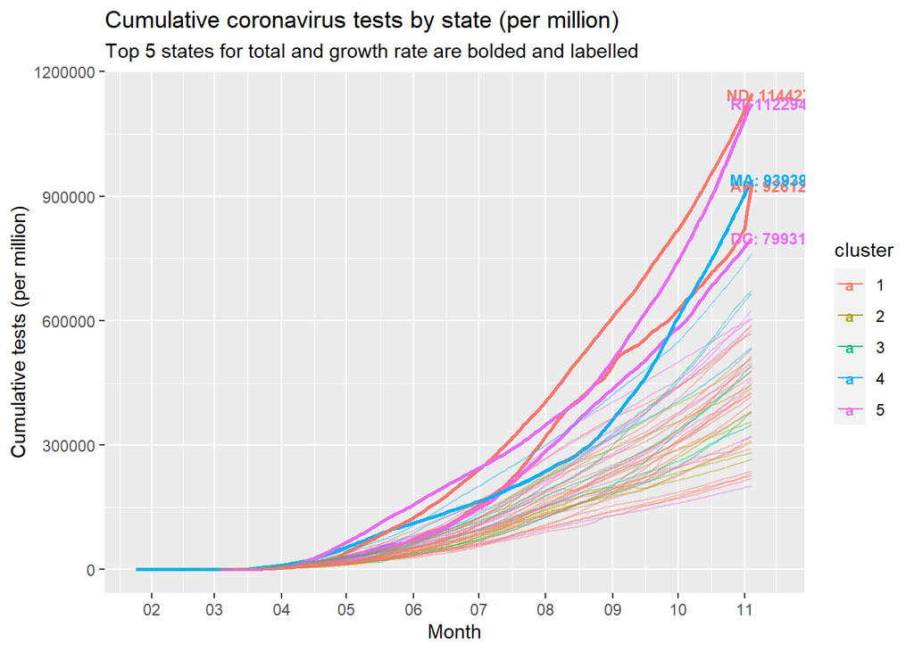

```r
saveToRDS(test_old_201108, ovrWriteError=FALSE)
```

Cases appear to be spiking in some of the states in the segment that had previously been less impacted. Hospitalizations in aggregate in this segment are starting to slope upwards, though not yet at the same rate as the increase in cases.

New data from USA Facts are downloaded and assessed against the existing county-level segments:

```r
# Locations for the population, case, and death file
popLoc <- "./RInputFiles/Coronavirus/covid_county_population_usafacts.csv"
caseLoc <- "./RInputFiles/Coronavirus/covid_confirmed_usafacts_downloaded_20201109.csv"
deathLoc <- "./RInputFiles/Coronavirus/covid_deaths_usafacts_downloaded_20201109.csv"

# Run old segments against new data
cty_old_20201109 <- readRunUSAFacts(maxDate="2020-11-07",
                                    popLoc=popLoc,
                                    caseLoc=caseLoc,
                                    deathLoc=deathLoc,
                                    dlCaseDeath=!(file.exists(caseLoc) & file.exists(deathLoc)),
                                    oldFile=readFromRDS("cty_20201026")$dfBurden,
                                    existingCountyClusters=readFromRDS("cty_20201026")$clustVec
                                    )
```

```
## Rows: 929,745
## Columns: 6
## $ countyFIPS <dbl> 0, 0, 0, 0, 0, 0, 0, 0, 0, 0, 0, 0, 0, 0, 0, 0, 0, 0, 0,...
## $ countyName <chr> "Statewide Unallocated", "Statewide Unallocated", "State...
## $ state      <chr> "AL", "AL", "AL", "AL", "AL", "AL", "AL", "AL", "AL", "A...
## $ stateFIPS  <dbl> 1, 1, 1, 1, 1, 1, 1, 1, 1, 1, 1, 1, 1, 1, 1, 1, 1, 1, 1,...
## $ date       <date> 2020-01-22, 2020-01-23, 2020-01-24, 2020-01-25, 2020-01...
## $ cumCases   <dbl> 0, 0, 0, 0, 0, 0, 0, 0, 0, 0, 0, 0, 0, 0, 0, 0, 0, 0, 0,...
```

```
## Rows: 929,745
## Columns: 6
## $ countyFIPS <dbl> 0, 0, 0, 0, 0, 0, 0, 0, 0, 0, 0, 0, 0, 0, 0, 0, 0, 0, 0,...
## $ countyName <chr> "Statewide Unallocated", "Statewide Unallocated", "State...
## $ state      <chr> "AL", "AL", "AL", "AL", "AL", "AL", "AL", "AL", "AL", "A...
## $ stateFIPS  <dbl> 1, 1, 1, 1, 1, 1, 1, 1, 1, 1, 1, 1, 1, 1, 1, 1, 1, 1, 1,...
## $ date       <date> 2020-01-22, 2020-01-23, 2020-01-24, 2020-01-25, 2020-01...
## $ cumDeaths  <dbl> 0, 0, 0, 0, 0, 0, 0, 0, 0, 0, 0, 0, 0, 0, 0, 0, 0, 0, 0,...
```

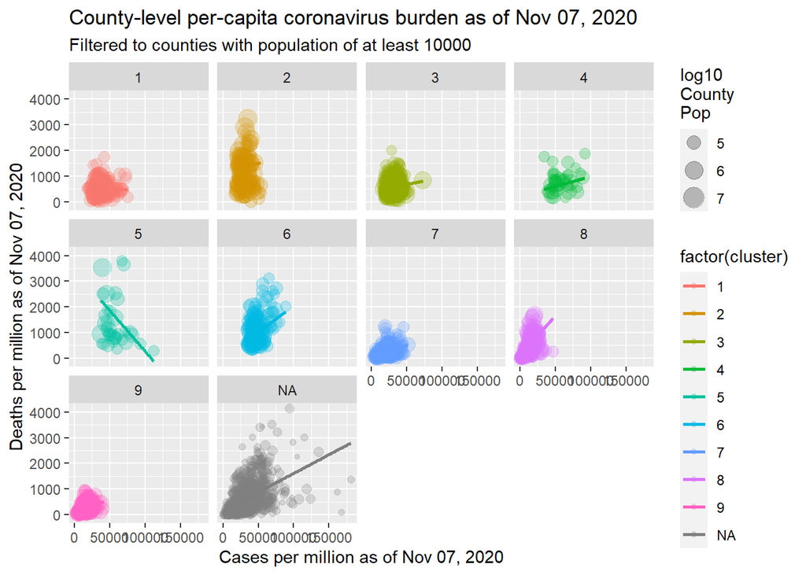

```
##
## Shapes will be created without any floor on the number of cases per million
## Shapes will be created without any floor on the number of deaths per million
## *** Counties with 0 cases/deaths or that fall below the floor for minCase/minDeath ***
## # A tibble: 1 x 4
##   cpm_mean_is0 dpm_mean_is0 dpm_mean_ltDeath cpm_mean_ltCase
##          <dbl>        <dbl>            <dbl>           <dbl>
## 1            0           NA               NA               0
```

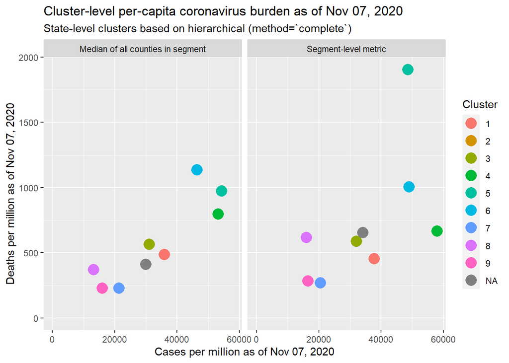

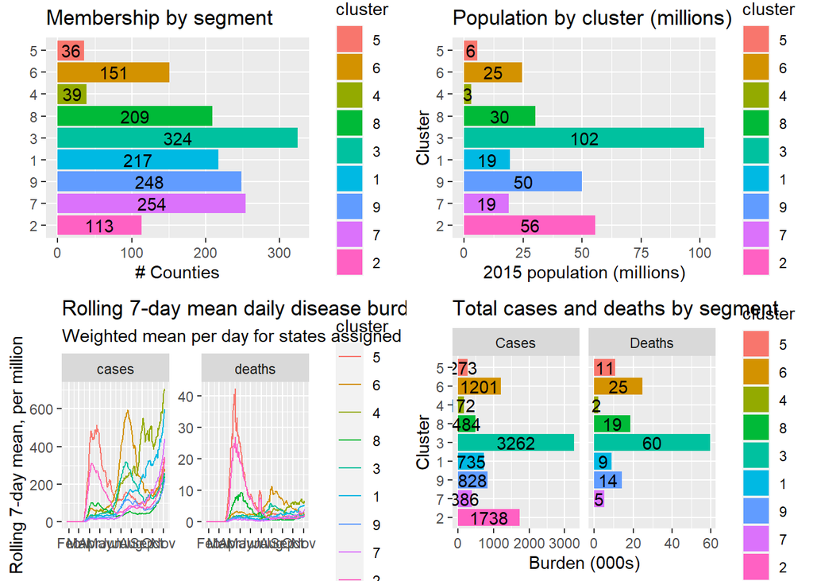

```
##
## Recency is defined as 2020-10-09 through current
##
## Recency is defined as 2020-10-09 through current
```

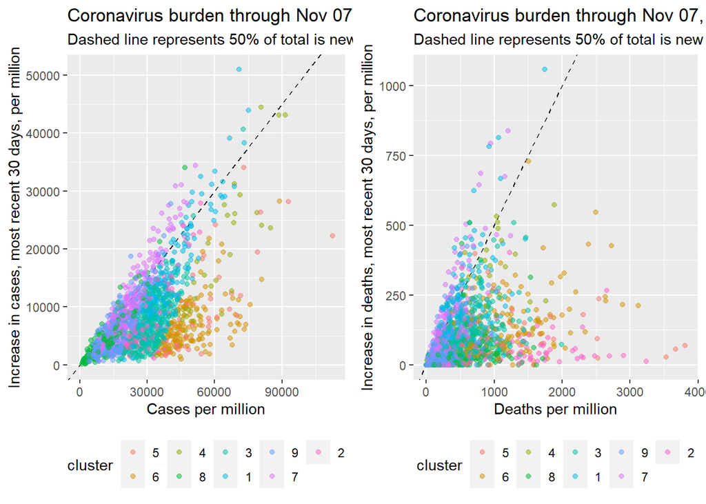

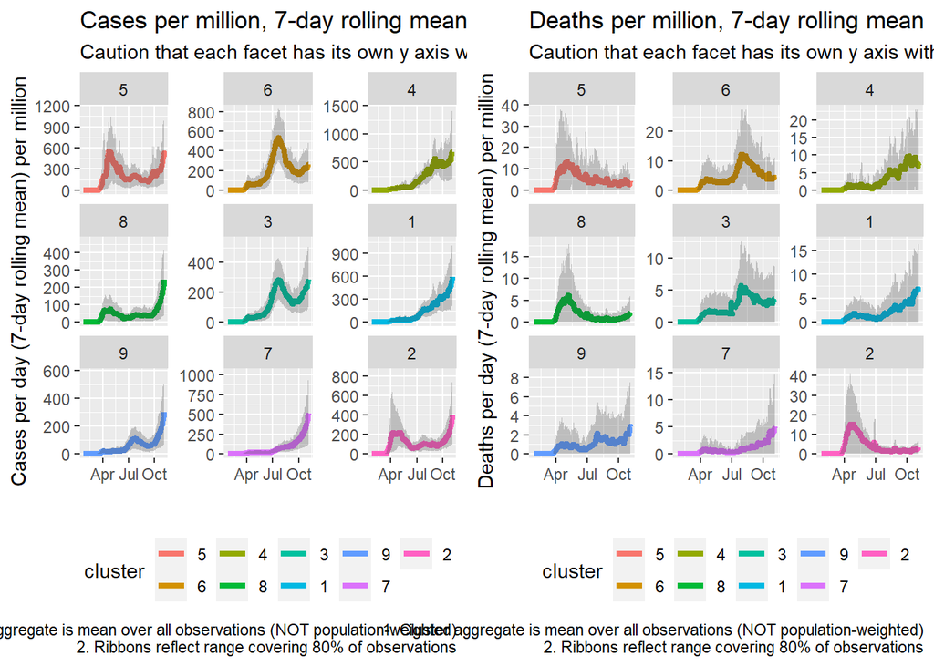

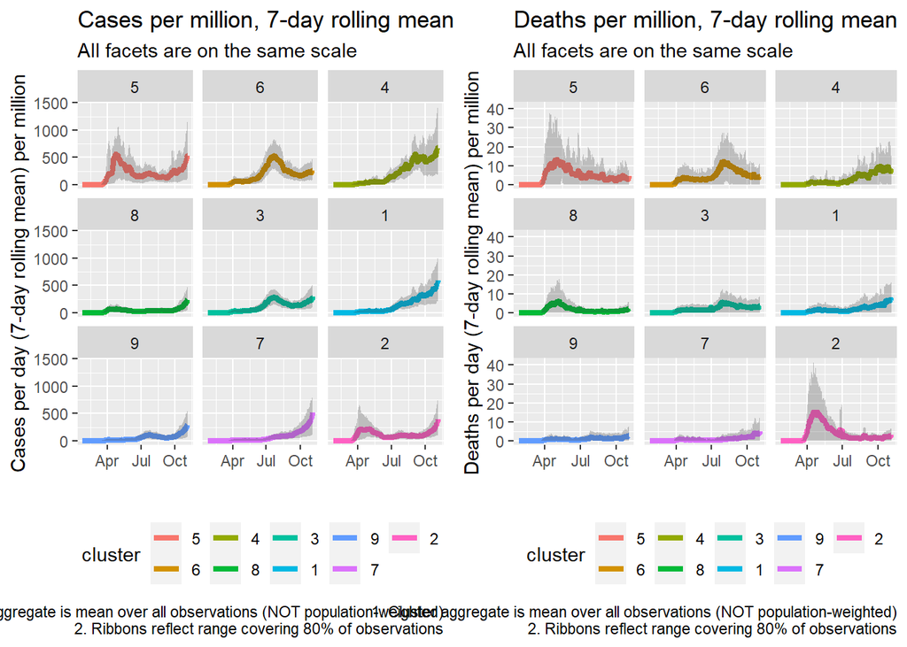

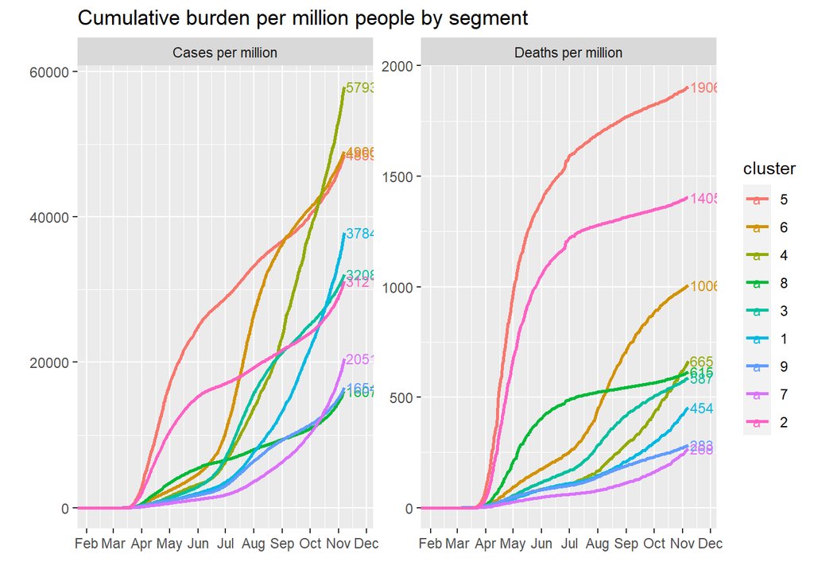

```r
saveToRDS(cty_old_20201109, ovrWriteError=FALSE)
```

```
##
## File already exists: ./RInputFiles/Coronavirus/cty_old_20201109.RDS
##
## Not replacing the existing file since ovrWrite=FALSE
```

Cases appear to be growing in many of the county clusters, though deaths per million per day remain well below the peaks observed in April in the earlier-hit counties.